# Assignment 9: Final Project

## Computational Methods in Psychology (and Neuroscience)

### Psychology 4500/7559 --- Fall 2020

# Objectives

Upon completion of this assignment, students will have:

1. Described the list generation process in detail
2. Described the experiment details
3. Visualized processed data
4. Performed a statistical analysis to test the hypothesis

# Assignment

Write text (in MarkDown cells) and code (in Code cells) in a Jupyter notebook (after making a copy and renaming it to have your userid in the title --- e.g., A09_Final_Project_mst3k).

## Details

The goal of the final project is to synthesize material covered in the class and produce part of what would go into an actual scientific publication based on *one* of the experiments we ran in the class. Specifically, you will be writing part of the Methods and Results sections.

The basic template is below the code for loading and processing the data. There we outline what each section should include. As always, make sure to label all figures and be sure to refer to the code in the lesson notebooks as a guide for your analyses.

Please feel free to reach out to us on Slack if you have any questions along the way.

- *When you are done, save this notebook as HTML (`File -> Download as -> HTML`) and upload it to the matching assignment on UVACollab.*

## General Imports

```python
# import some useful libraries
import numpy as np                # numerical analysis linear algebra
import pandas as pd               # efficient tables
import matplotlib.pyplot as plt   # plotting
import plotnine as pn
import scipy.stats.distributions as dists     # probability distributions
from scipy import stats
from glob import glob
import os
import statsmodels.formula.api as smf
import statsmodels.api as sm

from smile.log import log2dl

from ci_within import ci_within
```

## Custom SLOG loading function

```python
# custom function to load slogs
def load_all_subj_logs(task_dir, log_file):
    # load in a list of all the subj
    subjs = [os.path.split(subj_dir)[-1]
             for subj_dir in glob(os.path.join(task_dir, 's*'))]
    subjs.sort()

    # loop over subj and their data
    all_dat = []
    for subj in subjs:
        # set the file
        log_path = os.path.join(task_dir, subj, log_file)
        #print(log_path)

        # load the data
        all_dat.extend(log2dl(log_path, subj=subj))

    df = pd.DataFrame(all_dat)

    return df
```

## Load in all the data

```python
# load the data from the word recog task
task_dir = os.path.join('..', 'lessons', 'data', 'Taskapalooza')

df_f = load_all_subj_logs(task_dir, 'log_flanker')
df_i = load_all_subj_logs(task_dir, 'log_image_test')
df_w = load_all_subj_logs(task_dir, 'log_word_test')
df_f.head()
```

|  | resp_map_left | resp_map_right | block_num | trial_num | stim_on_time | stim_on_error | resp | resp_time_time | resp_time_error | rt | correct | location_0 | location_1 | log_time | condition | direction | stimulus | subj | log_num |
| --- | --- | --- | --- | --- | --- | --- | --- | --- | --- | --- | --- | --- | --- | --- | --- | --- | --- | --- | --- |
| 0 | F | J | 0 | 0 | 1829.983096 | 0.0 | F | 1830.614606 | 0.000206 | 0.631509 | True | 1124.413938 | 852.384884 | 1831.313423 | neutral | left | ===<=== | s001 | 0 |
| 1 | F | J | 0 | 1 | 1831.320258 | 0.0 | J | 1831.708334 | 0.000181 | 0.388076 | True | 1488.898432 | 948.599964 | 1832.235087 | neutral | right | ===>=== | s001 | 0 |
| 2 | F | J | 0 | 2 | 1832.244198 | 0.0 | F | 1832.818232 | 0.000197 | 0.574034 | True | 1853.572485 | 748.901092 | 1833.391370 | neutral | left | ===<=== | s001 | 0 |
| 3 | F | J | 0 | 3 | 1833.404586 | 0.0 | F | 1833.990549 | 0.000203 | 0.585963 | True | 1413.608109 | 996.704422 | 1834.859940 | neutral | left | ===<=== | s001 | 0 |
| 4 | F | J | 0 | 4 | 1834.876087 | 0.0 | F | 1835.262948 | 0.000186 | 0.386861 | True | 1557.565574 | 686.474531 | 1836.017047 | neutral | left | ===<=== | s001 | 0 |

## Some data clean-up

```python
# it turns out the cond is easier to visualize as pure and mixed
def fix_conds(df, type_col):
    # loop over the unique subjects
    usubj = df.subj.unique()
    for s in usubj:
        # loop over their blocks
        ublocks = df.loc[df['subj']==s, 'block_num'].unique()
        for b in ublocks:
            # grab the data for that subj and block
            dfb = df.loc[(df['subj']==s)&(df['block_num']==b)]

            # get the unique types in that block
            uval = dfb[type_col].unique()
            if len(uval) > 1:
                # it's mixed
                df.loc[(df['subj']==s)&(df.block_num==b), 'cond'] = 'mixed'
            else:
                # it's the pure
                df.loc[(df['subj']==s)&(df.block_num==b), 'cond'] = 'pure'

# fix the conds in the recog experiments (updated in place)
fix_conds(df_i, type_col='in_out')
fix_conds(df_w, type_col='valence')

# add in log_rt columns
df_f['log_rt'] = np.log(df_f['rt'])
df_i['log_rt'] = np.log(df_i['rt'])
df_w['log_rt'] = np.log(df_w['rt'])

# must make correct an int
df_f['correct'] = df_f['correct'].astype(np.int)
df_i['correct'] = df_i['correct'].astype(np.int)
df_w['correct'] = df_w['correct'].astype(np.int)

# add in a column for whether they made an 'old' response
df_i['old_resp'] = (df_i['resp_map_target'] == df_i['resp']).astype(np.int)
df_w['old_resp'] = (df_w['resp_map_target'] == df_w['resp']).astype(np.int)

# process some of the valence info
df_w['valence_mean'] = df_w['valence_mean'].astype(np.float)
df_w['arousal_mean'] = df_w['arousal_mean'].astype(np.float)
df_w['dominance_mean'] = df_w['dominance_mean'].astype(np.float)
df_w['abs_valence'] = np.abs(df_w['valence_mean'] - 5.0)
df_w['abs_arousal'] = np.abs(df_w['arousal_mean'] - 5.0)

df_f.head()
```

|  | resp_map_left | resp_map_right | block_num | trial_num | stim_on_time | stim_on_error | resp | resp_time_time | resp_time_error | rt | correct | location_0 | location_1 | log_time | condition | direction | stimulus | subj | log_num | log_rt |
| --- | --- | --- | --- | --- | --- | --- | --- | --- | --- | --- | --- | --- | --- | --- | --- | --- | --- | --- | --- | --- |
| 0 | F | J | 0 | 0 | 1829.983096 | 0.0 | F | 1830.614606 | 0.000206 | 0.631509 | 1 | 1124.413938 | 852.384884 | 1831.313423 | neutral | left | ===<=== | s001 | 0 | -0.459643 |
| 1 | F | J | 0 | 1 | 1831.320258 | 0.0 | J | 1831.708334 | 0.000181 | 0.388076 | 1 | 1488.898432 | 948.599964 | 1832.235087 | neutral | right | ===>=== | s001 | 0 | -0.946554 |
| 2 | F | J | 0 | 2 | 1832.244198 | 0.0 | F | 1832.818232 | 0.000197 | 0.574034 | 1 | 1853.572485 | 748.901092 | 1833.391370 | neutral | left | ===<=== | s001 | 0 | -0.555066 |
| 3 | F | J | 0 | 3 | 1833.404586 | 0.0 | F | 1833.990549 | 0.000203 | 0.585963 | 1 | 1413.608109 | 996.704422 | 1834.859940 | neutral | left | ===<=== | s001 | 0 | -0.534499 |
| 4 | F | J | 0 | 4 | 1834.876087 | 0.0 | F | 1835.262948 | 0.000186 | 0.386861 | 1 | 1557.565574 | 686.474531 | 1836.017047 | neutral | left | ===<=== | s001 | 0 | -0.949690 |

# Hypothesis

### Direction has an effect on perception accuracy.

# Methods

## List generation and SMILE

```
The flanker test tests the roles of attention and cognitive control in decision-making. The flanker test has three conditions that are presented: congruent (same response as target), incongruent (opposite response of target), and neutral (neither have same response). The arrow directions consist of right and left. From here we will create a dictionary of three keys as condition, direction, and the stimulus image. In each given block, we presented 12 trials of each condition. We then will randomize the order and this is how it will be presented to the participant.
The experiment was programmed in SMILE. The stimulus was presented on the screen for 1.5 seconds. The response keys for the participant to press are assigned the 'F' (left arrow) and 'J' (right arrow) keys. The participant was given these directions to associate the key press with the central target in the stimulus that was presented. Finally, the inter-response time interval was 0.5 seconds.
```

# Results

##### Are there differences in accuracy between directions?

##### IV: direction

##### DV: perception performance (correct)

## Data processing and visualization

*With the lessons as a guide, process your data to create the necessary data frame to plot the visualization associated with the question stated above. Then plot those data.*

```python
fperf = df_f.groupby(['subj', 'direction'])['correct'].agg(['sum', 'count', 'mean'])
fperf['binom_pval'] = fperf.apply(lambda x: stats.binom_test(x['sum'], n=x['count'],
                                                             p=0.5, alternative='two-sided'),
                                  axis=1)
fperf
```

| subj | direction | sum | count | mean | binom_pval |
| --- | --- | --- | --- | --- | --- |
| s001 | left | 131 | 144 | 0.909722 | 1.045643e-25 |
|  | right | 138 | 144 | 0.958333 | 1.044095e-33 |
| s002 | left | 139 | 144 | 0.965278 | 4.472363e-35 |
|  | right | 141 | 144 | 0.979167 | 4.464290e-38 |
| s003 | left | 143 | 144 | 0.993056 | 1.300405e-41 |
|  | right | 144 | 144 | 1.000000 | 8.968310e-44 |
| s004 | left | 142 | 144 | 0.986111 | 9.363813e-40 |
|  | right | 141 | 144 | 0.979167 | 4.464290e-38 |
| s005 | left | 131 | 144 | 0.909722 | 1.045643e-25 |
|  | right | 131 | 144 | 0.909722 | 1.045643e-25 |
| s006 | left | 139 | 144 | 0.965278 | 4.472363e-35 |
|  | right | 140 | 144 | 0.972222 | 1.585298e-36 |
| s007 | left | 142 | 144 | 0.986111 | 9.363813e-40 |
|  | right | 142 | 144 | 0.986111 | 9.363813e-40 |
| s008 | left | 135 | 144 | 0.937500 | 5.456553e-30 |
|  | right | 143 | 144 | 0.993056 | 1.300405e-41 |
| s009 | left | 141 | 144 | 0.979167 | 4.464290e-38 |
|  | right | 141 | 144 | 0.979167 | 4.464290e-38 |
| s010 | left | 141 | 144 | 0.979167 | 4.464290e-38 |
|  | right | 141 | 144 | 0.979167 | 4.464290e-38 |
| s011 | left | 141 | 144 | 0.979167 | 4.464290e-38 |
|  | right | 143 | 144 | 0.993056 | 1.300405e-41 |
| s012 | left | 143 | 144 | 0.993056 | 1.300405e-41 |
|  | right | 141 | 144 | 0.979167 | 4.464290e-38 |
| s013 | left | 141 | 144 | 0.979167 | 4.464290e-38 |
|  | right | 143 | 144 | 0.993056 | 1.300405e-41 |
| s014 | left | 133 | 144 | 0.923611 | 9.127422e-28 |
|  | right | 133 | 144 | 0.923611 | 9.127422e-28 |
| s015 | left | 134 | 144 | 0.930556 | 7.428512e-29 |
|  | right | 142 | 144 | 0.986111 | 9.363813e-40 |
| s016 | left | 143 | 144 | 0.993056 | 1.300405e-41 |
|  | right | 143 | 144 | 0.993056 | 1.300405e-41 |
| s017 | left | 130 | 144 | 0.902778 | 9.874919e-25 |
|  | right | 134 | 144 | 0.930556 | 7.428512e-29 |
| s018 | left | 143 | 144 | 0.993056 | 1.300405e-41 |
|  | right | 144 | 144 | 1.000000 | 8.968310e-44 |
| s019 | left | 143 | 144 | 0.993056 | 1.300405e-41 |
|  | right | 144 | 144 | 1.000000 | 8.968310e-44 |
| s020 | left | 143 | 144 | 0.993056 | 1.300405e-41 |
|  | right | 141 | 144 | 0.979167 | 4.464290e-38 |
| s021 | left | 137 | 144 | 0.951389 | 2.074599e-32 |
|  | right | 138 | 144 | 0.958333 | 1.044095e-33 |
| s022 | left | 140 | 144 | 0.972222 | 1.585298e-36 |
|  | right | 140 | 144 | 0.972222 | 1.585298e-36 |
| s023 | left | 108 | 144 | 0.750000 | 1.495759e-09 |
|  | right | 110 | 144 | 0.763889 | 1.519592e-10 |

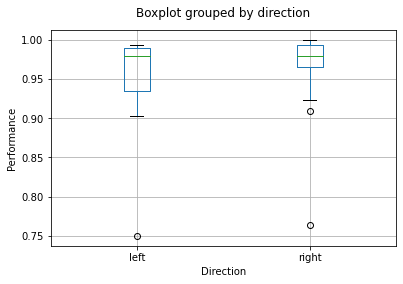

```python
# Let's make a boxplot of the performance values
ax = fperf.boxplot(column='mean', by=['direction'])
ax.set_title('')
ax.set_ylabel('Performance')
ax.set_xlabel('Direction')
```

###### Interpretation: The performance values based on direction seem to have similar values around the .97-.99 range with one severe outlier in each direction at the 0.75 range. One cannot make any immediate assumptions if there is a strong relationship or not but it gives us at least some clarity that there is not one direction that does better than the other.

## Statistical test and interpretation

*Perform a statistical test to support your conclusions with regard to your question outlined above. This can be with either statsmodels or with bambi.*

```python
# first we need to get summary values for each subj
sum_df = df_f.groupby(['subj', 'direction'])['correct'].mean().reset_index()
sum_df
```

|  | subj | direction | correct |
| --- | --- | --- | --- |
| 0 | s001 | left | 0.909722 |
| 1 | s001 | right | 0.958333 |
| 2 | s002 | left | 0.965278 |
| 3 | s002 | right | 0.979167 |
| 4 | s003 | left | 0.993056 |
| 5 | s003 | right | 1.000000 |
| 6 | s004 | left | 0.986111 |
| 7 | s004 | right | 0.979167 |
| 8 | s005 | left | 0.909722 |
| 9 | s005 | right | 0.909722 |
| 10 | s006 | left | 0.965278 |
| 11 | s006 | right | 0.972222 |
| 12 | s007 | left | 0.986111 |
| 13 | s007 | right | 0.986111 |
| 14 | s008 | left | 0.937500 |
| 15 | s008 | right | 0.993056 |
| 16 | s009 | left | 0.979167 |
| 17 | s009 | right | 0.979167 |
| 18 | s010 | left | 0.979167 |
| 19 | s010 | right | 0.979167 |
| 20 | s011 | left | 0.979167 |
| 21 | s011 | right | 0.993056 |
| 22 | s012 | left | 0.993056 |
| 23 | s012 | right | 0.979167 |
| 24 | s013 | left | 0.979167 |
| 25 | s013 | right | 0.993056 |
| 26 | s014 | left | 0.923611 |
| 27 | s014 | right | 0.923611 |
| 28 | s015 | left | 0.930556 |
| 29 | s015 | right | 0.986111 |
| 30 | s016 | left | 0.993056 |
| 31 | s016 | right | 0.993056 |
| 32 | s017 | left | 0.902778 |
| 33 | s017 | right | 0.930556 |
| 34 | s018 | left | 0.993056 |
| 35 | s018 | right | 1.000000 |
| 36 | s019 | left | 0.993056 |
| 37 | s019 | right | 1.000000 |
| 38 | s020 | left | 0.993056 |
| 39 | s020 | right | 0.979167 |
| 40 | s021 | left | 0.951389 |
| 41 | s021 | right | 0.958333 |
| 42 | s022 | left | 0.972222 |
| 43 | s022 | right | 0.972222 |
| 44 | s023 | left | 0.750000 |
| 45 | s023 | right | 0.763889 |

```python
# build a least squares regression
model = smf.ols("correct ~ direction", sum_df).fit()
model.summary()
```

OLS Regression Results

| Dep. Variable: | correct | R-squared: | 0.011 |
| --- | --- | --- | --- |
| Model: | OLS | Adj. R-squared: | -0.012 |
| Method: | Least Squares | F-statistic: | 0.4720 |
| Date: | Mon, 07 Dec 2020 | Prob (F-statistic): | 0.496 |
| Time: | 16:52:48 | Log-Likelihood: | 71.606 |
| No. Observations: | 46 | AIC: | -139.2 |
| Df Residuals: | 44 | BIC: | -135.6 |
| Df Model: | 1 |  |  |
| Covariance Type: | nonrobust |  |  |

|  | coef | std err | t | P>\|t\| | [0.025 | 0.975] |
| --- | --- | --- | --- | --- | --- | --- |
| Intercept | 0.9550 | 0.011 | 87.801 | 0.000 | 0.933 | 0.977 |
| direction[T.right] | 0.0106 | 0.015 | 0.687 | 0.496 | -0.020 | 0.042 |

| Omnibus: | 47.738 | Durbin-Watson: | 0.676 |
| --- | --- | --- | --- |
| Prob(Omnibus): | 0.000 | Jarque-Bera (JB): | 185.429 |
| Skew: | -2.750 | Prob(JB): | 5.43e-41 |
| Kurtosis: | 11.154 | Cond. No. | 2.62 |

Notes:  
[1] Standard Errors assume that the covariance matrix of the errors is correctly specified.

```python
sm.stats.anova_lm(model, typ=2)
```

|  | sum_sq | df | F | PR(>F) |
| --- | --- | --- | --- | --- |
| direction | 0.001284 | 1.0 | 0.471962 | 0.495691 |
| Residual | 0.119729 | 44.0 | NaN | NaN |

###### Conclusion: Our statistical tests included a linear regression model correct responses as a function of direction and also a type 2 anova test to follow up. From the linear regression model, we get a F stat value of 0.4720 and our predictor value of direction has a value of 0.496. Using our usual alpha level of 0.05, we cannot conclude that direction is statistically significant in assessing the accuracy of the flanker test. Consequently, our anova type 2 test shows the same answer as the linear regression model results and validates that direction might not be a good predictor by itself. It could useful for future research to explore its interactions with conditions or maybe subsetting certain conditions with just one direction and analyzing that impact.

# Discussion

*Graduate students only!!!*

*In one to two paragraphs do the following: a) Place the study in the larger literature, summarizing some of the similar work in the field and how this study compares, b) write some analysis of the findings from the study (even if they are null results) and then describe a follow-up study with a new variant of the experiment that you think might help answer further questions on the topic.